# Bad Movie? The most ambitious crossover event since 2018.

Author: Jake Mraz

## Introduction

In this tutorial I will be examining one of my favorite things, movies. For a while now I have been able to watch a movie trailer and predict if the movie would do well or not, like calling that Ghostbusters was going to be awful or that Batman the Dark Knight would be awesome. While I had these feelings, I wondered if I could prove this with data. So for this I will be examining if it is possible to predict a movies success, or better yet, will a movie fail?  
Of course we first need to explain what a failure is to a movie. A naturally simple way to define this is a movie which loses money. Defining a success is a little more tricky since there is no definitive point where a movie can be considered success, but we also know we would not consider a movie a complete failure if it were able to cover loss. Since I will be dealing mostly with prediciting if a movie will fail, and defining success is mostly subjective, I will leave this definition up to you.

## Outline

1. Organizing Data
2. Important Information for those who skipped part 1
3. Exploring Ratings and Profit
4. Exploring Data & Predicting Failures
5. Conclusion
6. All required libraries and links to external sources

## 1. Organizing Data

```python
#Import required libraries
import pandas as pd
import numpy as np
import json
import ast
import warnings
warnings.filterwarnings('ignore') #Used this to hide expected warnings
```

We are going to begin by importing the movie data. I recieved my data from separate sources and because of this, I need both files to gather the data I need from each source. During this section I will be focused on condesning the data down and lining up all IDs to make moving between various datasources easier.  
You will notice some similarities between the datasets, this is because the data which will be put into movies_df is based off of the data from MovieLens, but examines some parts further while ignoring other parts. Below you can find links to the data. I will also include the links used throughout this tutorial in a section at the bottom.  
Kaggle Movies Data: https://www.kaggle.com/rounakbanik/the-movies-dataset variables dealing with this data will begin with a 'k'  
MovieLens Data: https://grouplens.org/datasets/movielens/latest/ variables dealing with this data will begin with 'm'

```python
###Gathering movie data####
#Read movie metadata from Kaggle into a dataframe
k_movies_df = pd.read_csv('/home/jovyan/notebooks/Movies/movies_metadata.csv')
#Getting MovieLens Data
m_movies_df = pd.read_csv('/home/jovyan/notebooks/MovieLens/movies.csv')

###Gather Ratings data
#Data from Kaggle
k_ratings_df = pd.read_csv('/home/jovyan/notebooks/Movies/ratings.csv')

###Gathering Tags and Tag Genome data
m_tags_df = pd.read_csv('/home/jovyan/notebooks/MovieLens/genome-tags.csv')
m_scores_df = pd.read_csv('/home/jovyan/notebooks/MovieLens/genome-scores.csv')
```

Now that we have read our data into data frame, we will want to clean noisy data. We will begin by printing out the columns of each dataframe to see which ones we do not need. This should also help to give a good idea of what information each dataframe has.

```python
print("Movies")
print("K movies: ", k_movies_df.columns)
print("M movies: ",  m_movies_df.columns)

print("\nRatings")
print("K movies: ", k_ratings_df.columns)

print("\nTags")
print("Tags: ", m_tags_df.columns)
print("Scores: ",  m_scores_df.columns)
```

```
Movies
K movies:  Index(['adult', 'belongs_to_collection', 'budget', 'genres', 'homepage', 'id',
       'imdb_id', 'original_language', 'original_title', 'overview',
       'popularity', 'poster_path', 'production_companies',
       'production_countries', 'release_date', 'revenue', 'runtime',
       'spoken_languages', 'status', 'tagline', 'title', 'video',
       'vote_average', 'vote_count'],
      dtype='object')
M movies:  Index(['movieId', 'title', 'genres'], dtype='object')

Ratings
K movies:  Index(['userId', 'movieId', 'rating', 'timestamp'], dtype='object')

Tags
Tags:  Index(['tagId', 'tag'], dtype='object')
Scores:  Index(['movieId', 'tagId', 'relevance'], dtype='object')
```

We can see that the Kaggle dataset has more information than we need. We will trim this down to the data I do need from this soon. Also notice the 'timestamp' column in the ratings dataframes, this just refers to when the user made their rating, so this will also be dropped.  
Now lets look at the size of each dataframe by examining the amount of rows or entries they have.

```python
print("Movies")
print("K movies: ", len(k_movies_df.index))
print("M movies: ", len(m_movies_df.index))

print("\nRatings")
print("K movies: ", len(k_ratings_df.index))


print("\nTags")
print("Tags: ", len(m_tags_df.index))
print("Scores: ",  len(m_scores_df.index))
```

```
Movies
K movies:  45466
M movies:  58098

Ratings
K movies:  26024289

Tags
Tags:  1128
Scores:  14862528
```

```python
#Basic columns needed to tell us about the movies in K
k_df_identify = ["id","title","release_date", 'genres']
#And then we will take columns to help us learn more about its prodution
k_df_identify = k_df_identify + ['production_companies', 'budget','revenue','runtime','status']

k_movies_df[k_df_identify]
```

|  | id | title | release_date | genres | production_companies | budget | revenue | runtime | status |
| --- | --- | --- | --- | --- | --- | --- | --- | --- | --- |
| 0 | 862 | Toy Story | 1995-10-30 | [{'id': 16, 'name': 'Animation'}, {'id': 35, '... | [{'name': 'Pixar Animation Studios', 'id': 3}] | 30000000 | 373554033.0 | 81.0 | Released |
| 1 | 8844 | Jumanji | 1995-12-15 | [{'id': 12, 'name': 'Adventure'}, {'id': 14, '... | [{'name': 'TriStar Pictures', 'id': 559}, {'na... | 65000000 | 262797249.0 | 104.0 | Released |
| 2 | 15602 | Grumpier Old Men | 1995-12-22 | [{'id': 10749, 'name': 'Romance'}, {'id': 35, ... | [{'name': 'Warner Bros.', 'id': 6194}, {'name'... | 0 | 0.0 | 101.0 | Released |
| 3 | 31357 | Waiting to Exhale | 1995-12-22 | [{'id': 35, 'name': 'Comedy'}, {'id': 18, 'nam... | [{'name': 'Twentieth Century Fox Film Corporat... | 16000000 | 81452156.0 | 127.0 | Released |
| 4 | 11862 | Father of the Bride Part II | 1995-02-10 | [{'id': 35, 'name': 'Comedy'}] | [{'name': 'Sandollar Productions', 'id': 5842}... | 0 | 76578911.0 | 106.0 | Released |
| 5 | 949 | Heat | 1995-12-15 | [{'id': 28, 'name': 'Action'}, {'id': 80, 'nam... | [{'name': 'Regency Enterprises', 'id': 508}, {... | 60000000 | 187436818.0 | 170.0 | Released |
| 6 | 11860 | Sabrina | 1995-12-15 | [{'id': 35, 'name': 'Comedy'}, {'id': 10749, '... | [{'name': 'Paramount Pictures', 'id': 4}, {'na... | 58000000 | 0.0 | 127.0 | Released |
| 7 | 45325 | Tom and Huck | 1995-12-22 | [{'id': 28, 'name': 'Action'}, {'id': 12, 'nam... | [{'name': 'Walt Disney Pictures', 'id': 2}] | 0 | 0.0 | 97.0 | Released |
| 8 | 9091 | Sudden Death | 1995-12-22 | [{'id': 28, 'name': 'Action'}, {'id': 12, 'nam... | [{'name': 'Universal Pictures', 'id': 33}, {'n... | 35000000 | 64350171.0 | 106.0 | Released |
| 9 | 710 | GoldenEye | 1995-11-16 | [{'id': 12, 'name': 'Adventure'}, {'id': 28, '... | [{'name': 'United Artists', 'id': 60}, {'name'... | 58000000 | 352194034.0 | 130.0 | Released |
| 10 | 9087 | The American President | 1995-11-17 | [{'id': 35, 'name': 'Comedy'}, {'id': 18, 'nam... | [{'name': 'Columbia Pictures', 'id': 5}, {'nam... | 62000000 | 107879496.0 | 106.0 | Released |
| 11 | 12110 | Dracula: Dead and Loving It | 1995-12-22 | [{'id': 35, 'name': 'Comedy'}, {'id': 27, 'nam... | [{'name': 'Columbia Pictures', 'id': 5}, {'nam... | 0 | 0.0 | 88.0 | Released |
| 12 | 21032 | Balto | 1995-12-22 | [{'id': 10751, 'name': 'Family'}, {'id': 16, '... | [{'name': 'Universal Pictures', 'id': 33}, {'n... | 0 | 11348324.0 | 78.0 | Released |
| 13 | 10858 | Nixon | 1995-12-22 | [{'id': 36, 'name': 'History'}, {'id': 18, 'na... | [{'name': 'Hollywood Pictures', 'id': 915}, {'... | 44000000 | 13681765.0 | 192.0 | Released |
| 14 | 1408 | Cutthroat Island | 1995-12-22 | [{'id': 28, 'name': 'Action'}, {'id': 12, 'nam... | [{'name': 'Le Studio Canal+', 'id': 183}, {'na... | 98000000 | 10017322.0 | 119.0 | Released |
| 15 | 524 | Casino | 1995-11-22 | [{'id': 18, 'name': 'Drama'}, {'id': 80, 'name... | [{'name': 'Universal Pictures', 'id': 33}, {'n... | 52000000 | 116112375.0 | 178.0 | Released |
| 16 | 4584 | Sense and Sensibility | 1995-12-13 | [{'id': 18, 'name': 'Drama'}, {'id': 10749, 'n... | [{'name': 'Columbia Pictures Corporation', 'id... | 16500000 | 135000000.0 | 136.0 | Released |
| 17 | 5 | Four Rooms | 1995-12-09 | [{'id': 80, 'name': 'Crime'}, {'id': 35, 'name... | [{'name': 'Miramax Films', 'id': 14}, {'name':... | 4000000 | 4300000.0 | 98.0 | Released |
| 18 | 9273 | Ace Ventura: When Nature Calls | 1995-11-10 | [{'id': 80, 'name': 'Crime'}, {'id': 35, 'name... | [{'name': 'O Entertainment', 'id': 5682}, {'na... | 30000000 | 212385533.0 | 90.0 | Released |
| 19 | 11517 | Money Train | 1995-11-21 | [{'id': 28, 'name': 'Action'}, {'id': 35, 'nam... | [{'name': 'Columbia Pictures', 'id': 5}] | 60000000 | 35431113.0 | 103.0 | Released |
| 20 | 8012 | Get Shorty | 1995-10-20 | [{'id': 35, 'name': 'Comedy'}, {'id': 53, 'nam... | [{'name': 'Jersey Films', 'id': 216}, {'name':... | 30250000 | 115101622.0 | 105.0 | Released |
| 21 | 1710 | Copycat | 1995-10-27 | [{'id': 18, 'name': 'Drama'}, {'id': 53, 'name... | [{'name': 'Regency Enterprises', 'id': 508}, {... | 0 | 0.0 | 124.0 | Released |
| 22 | 9691 | Assassins | 1995-10-06 | [{'id': 28, 'name': 'Action'}, {'id': 12, 'nam... | [{'name': 'Silver Pictures', 'id': 1885}, {'na... | 50000000 | 30303072.0 | 132.0 | Released |
| 23 | 12665 | Powder | 1995-10-27 | [{'id': 18, 'name': 'Drama'}, {'id': 14, 'name... | [{'name': 'Caravan Pictures', 'id': 175}, {'na... | 0 | 0.0 | 111.0 | Released |
| 24 | 451 | Leaving Las Vegas | 1995-10-27 | [{'id': 18, 'name': 'Drama'}, {'id': 10749, 'n... | [{'name': 'United Artists', 'id': 60}, {'name'... | 3600000 | 49800000.0 | 112.0 | Released |
| 25 | 16420 | Othello | 1995-12-15 | [{'id': 18, 'name': 'Drama'}] | [{'name': 'Columbia Pictures', 'id': 5}, {'nam... | 0 | 0.0 | 123.0 | Released |
| 26 | 9263 | Now and Then | 1995-10-20 | [{'id': 35, 'name': 'Comedy'}, {'id': 18, 'nam... | [{'name': 'New Line Cinema', 'id': 12}] | 12000000 | 27400000.0 | 100.0 | Released |
| 27 | 17015 | Persuasion | 1995-09-27 | [{'id': 18, 'name': 'Drama'}, {'id': 10749, 'n... | [{'name': 'BBC Films', 'id': 288}] | 0 | 0.0 | 104.0 | Released |
| 28 | 902 | The City of Lost Children | 1995-05-16 | [{'id': 14, 'name': 'Fantasy'}, {'id': 878, 'n... | [{'name': 'Procirep', 'id': 311}, {'name': 'Co... | 18000000 | 1738611.0 | 108.0 | Released |
| 29 | 37557 | Shanghai Triad | 1995-04-30 | [{'id': 18, 'name': 'Drama'}, {'id': 80, 'name... | [{'name': 'Ministère des Affaires Étrangères',... | 0 | 0.0 | 108.0 | Released |
| ... | ... | ... | ... | ... | ... | ... | ... | ... | ... |
| 45436 | 45527 | The Final Storm | 2010-01-01 | [{'id': 28, 'name': 'Action'}, {'id': 9648, 'n... | [{'name': 'Boll Kino Beteiligungs GmbH & Co. K... | 0 | 0.0 | 92.0 | Released |
| 45437 | 455661 | In a Heartbeat | 2017-06-01 | [{'id': 10751, 'name': 'Family'}, {'id': 16, '... | [{'name': 'Ringling College of Art and Design'... | 0 | 0.0 | 4.0 | Released |
| 45438 | 327237 | Blood, Sweat and Tears | 2015-04-02 | [{'id': 18, 'name': 'Drama'}] | [] | 0 | 0.0 | 111.0 | Released |
| 45439 | 84710 | Jungle Woman | 1944-06-01 | [{'id': 18, 'name': 'Drama'}, {'id': 14, 'name... | [{'name': 'Universal Pictures', 'id': 33}] | 0 | 0.0 | 61.0 | Released |
| 45440 | 39562 | To Be Fat Like Me | 2007-01-08 | [{'id': 18, 'name': 'Drama'}, {'id': 10751, 'n... | [] | 0 | 0.0 | 89.0 | Released |
| 45441 | 14008 | Cadet Kelly | 2002-03-07 | [{'id': 35, 'name': 'Comedy'}] | [{'name': 'Walt Disney Television', 'id': 670}... | 0 | 0.0 | 101.0 | Released |
| 45442 | 44330 | The Scheming Gambler's Paradise | 1905-01-01 | [] | [] | 0 | 0.0 | 3.0 | NaN |
| 45443 | 49279 | The Man with the Rubber Head | 1901-01-01 | [{'id': 35, 'name': 'Comedy'}, {'id': 14, 'nam... | [{'name': 'Star Film Company', 'id': 45867}] | 0 | 0.0 | 3.0 | Released |
| 45444 | 44333 | The Living Playing Cards | 1905-01-01 | [{'id': 14, 'name': 'Fantasy'}] | [{'name': 'Star-Film', 'id': 7159}] | 0 | 0.0 | 3.0 | Released |
| 45445 | 49277 | The Hilarious Posters | 1906-01-01 | [{'id': 14, 'name': 'Fantasy'}, {'id': 35, 'na... | [{'name': 'Star-Film', 'id': 7159}, {'name': '... | 0 | 0.0 | 3.0 | Released |
| 45446 | 49271 | The Devilish Tenant | 1909-01-01 | [{'id': 14, 'name': 'Fantasy'}, {'id': 35, 'na... | [{'name': 'Star Film Company', 'id': 45867}] | 0 | 0.0 | 6.0 | Released |
| 45447 | 44324 | The Untameable Whiskers | 1904-03-05 | [] | [{'name': 'Star Film Company', 'id': 45867}] | 0 | 0.0 | 3.0 | Released |
| 45448 | 122036 | The Imperceptable Transmutations | 1904-01-01 | [] | [{'name': 'Star Film Company', 'id': 45867}] | 0 | 0.0 | 2.0 | Released |
| 45449 | 14885 | Pooh's Heffalump Halloween Movie | 2005-09-13 | [{'id': 16, 'name': 'Animation'}, {'id': 10751... | [{'name': 'Walt Disney Pictures', 'id': 2}] | 0 | 0.0 | 67.0 | Released |
| 45450 | 49280 | The One-Man Band | 1900-01-01 | [{'id': 14, 'name': 'Fantasy'}, {'id': 28, 'na... | [{'name': 'Star Film Company', 'id': 45867}] | 0 | 0.0 | 1.0 | Released |
| 45451 | 106807 | The Fat and Lean Wrestling Match | 1900-01-01 | [{'id': 35, 'name': 'Comedy'}, {'id': 14, 'nam... | [{'name': 'Star-Film', 'id': 7159}] | 0 | 0.0 | 2.0 | Released |
| 45452 | 276895 | Deep Hearts | 1981-01-01 | [{'id': 99, 'name': 'Documentary'}] | [] | 0 | 0.0 | 58.0 | Released |
| 45453 | 404604 | Mom | 2017-07-07 | [{'id': 80, 'name': 'Crime'}, {'id': 18, 'name... | [{'name': 'Mad Films', 'id': 82459}, {'name': ... | 0 | 0.0 | 146.0 | Released |
| 45454 | 420346 | The Morning After | 2015-01-11 | [{'id': 35, 'name': 'Comedy'}, {'id': 18, 'nam... | [{'name': 'Oops Doughnuts Productions', 'id': ... | 0 | 0.0 | 79.0 | Released |
| 45455 | 67179 | St. Michael Had a Rooster | 1972-01-01 | [] | [] | 0 | 0.0 | 90.0 | Released |
| 45456 | 84419 | House of Horrors | 1946-03-29 | [{'id': 27, 'name': 'Horror'}, {'id': 9648, 'n... | [{'name': 'Universal Pictures', 'id': 33}] | 0 | 0.0 | 65.0 | Released |
| 45457 | 390959 | Shadow of the Blair Witch | 2000-10-22 | [{'id': 9648, 'name': 'Mystery'}, {'id': 27, '... | [] | 0 | 0.0 | 45.0 | Released |
| 45458 | 289923 | The Burkittsville 7 | 2000-10-03 | [{'id': 27, 'name': 'Horror'}] | [{'name': 'Neptune Salad Entertainment', 'id':... | 0 | 0.0 | 30.0 | Released |
| 45459 | 222848 | Caged Heat 3000 | 1995-01-01 | [{'id': 878, 'name': 'Science Fiction'}] | [{'name': 'Concorde-New Horizons', 'id': 4688}] | 0 | 0.0 | 85.0 | Released |
| 45460 | 30840 | Robin Hood | 1991-05-13 | [{'id': 18, 'name': 'Drama'}, {'id': 28, 'name... | [{'name': 'Westdeutscher Rundfunk (WDR)', 'id'... | 0 | 0.0 | 104.0 | Released |
| 45461 | 439050 | Subdue | NaN | [{'id': 18, 'name': 'Drama'}, {'id': 10751, 'n... | [] | 0 | 0.0 | 90.0 | Released |
| 45462 | 111109 | Century of Birthing | 2011-11-17 | [{'id': 18, 'name': 'Drama'}] | [{'name': 'Sine Olivia', 'id': 19653}] | 0 | 0.0 | 360.0 | Released |
| 45463 | 67758 | Betrayal | 2003-08-01 | [{'id': 28, 'name': 'Action'}, {'id': 18, 'nam... | [{'name': 'American World Pictures', 'id': 6165}] | 0 | 0.0 | 90.0 | Released |
| 45464 | 227506 | Satan Triumphant | 1917-10-21 | [] | [{'name': 'Yermoliev', 'id': 88753}] | 0 | 0.0 | 87.0 | Released |
| 45465 | 461257 | Queerama | 2017-06-09 | [] | [] | 0 | 0.0 | 75.0 | Released |

45466 rows × 9 columns

```python
#Since we see the list works and this dataframe is easier to manage, we will replace the old one
k_movies_df = k_movies_df[k_df_identify]
k_movies_df
```

|  | id | title | release_date | genres | production_companies | budget | revenue | runtime | status |
| --- | --- | --- | --- | --- | --- | --- | --- | --- | --- |
| 0 | 862 | Toy Story | 1995-10-30 | [{'id': 16, 'name': 'Animation'}, {'id': 35, '... | [{'name': 'Pixar Animation Studios', 'id': 3}] | 30000000 | 373554033.0 | 81.0 | Released |
| 1 | 8844 | Jumanji | 1995-12-15 | [{'id': 12, 'name': 'Adventure'}, {'id': 14, '... | [{'name': 'TriStar Pictures', 'id': 559}, {'na... | 65000000 | 262797249.0 | 104.0 | Released |
| 2 | 15602 | Grumpier Old Men | 1995-12-22 | [{'id': 10749, 'name': 'Romance'}, {'id': 35, ... | [{'name': 'Warner Bros.', 'id': 6194}, {'name'... | 0 | 0.0 | 101.0 | Released |
| 3 | 31357 | Waiting to Exhale | 1995-12-22 | [{'id': 35, 'name': 'Comedy'}, {'id': 18, 'nam... | [{'name': 'Twentieth Century Fox Film Corporat... | 16000000 | 81452156.0 | 127.0 | Released |
| 4 | 11862 | Father of the Bride Part II | 1995-02-10 | [{'id': 35, 'name': 'Comedy'}] | [{'name': 'Sandollar Productions', 'id': 5842}... | 0 | 76578911.0 | 106.0 | Released |
| 5 | 949 | Heat | 1995-12-15 | [{'id': 28, 'name': 'Action'}, {'id': 80, 'nam... | [{'name': 'Regency Enterprises', 'id': 508}, {... | 60000000 | 187436818.0 | 170.0 | Released |
| 6 | 11860 | Sabrina | 1995-12-15 | [{'id': 35, 'name': 'Comedy'}, {'id': 10749, '... | [{'name': 'Paramount Pictures', 'id': 4}, {'na... | 58000000 | 0.0 | 127.0 | Released |
| 7 | 45325 | Tom and Huck | 1995-12-22 | [{'id': 28, 'name': 'Action'}, {'id': 12, 'nam... | [{'name': 'Walt Disney Pictures', 'id': 2}] | 0 | 0.0 | 97.0 | Released |
| 8 | 9091 | Sudden Death | 1995-12-22 | [{'id': 28, 'name': 'Action'}, {'id': 12, 'nam... | [{'name': 'Universal Pictures', 'id': 33}, {'n... | 35000000 | 64350171.0 | 106.0 | Released |
| 9 | 710 | GoldenEye | 1995-11-16 | [{'id': 12, 'name': 'Adventure'}, {'id': 28, '... | [{'name': 'United Artists', 'id': 60}, {'name'... | 58000000 | 352194034.0 | 130.0 | Released |
| 10 | 9087 | The American President | 1995-11-17 | [{'id': 35, 'name': 'Comedy'}, {'id': 18, 'nam... | [{'name': 'Columbia Pictures', 'id': 5}, {'nam... | 62000000 | 107879496.0 | 106.0 | Released |
| 11 | 12110 | Dracula: Dead and Loving It | 1995-12-22 | [{'id': 35, 'name': 'Comedy'}, {'id': 27, 'nam... | [{'name': 'Columbia Pictures', 'id': 5}, {'nam... | 0 | 0.0 | 88.0 | Released |
| 12 | 21032 | Balto | 1995-12-22 | [{'id': 10751, 'name': 'Family'}, {'id': 16, '... | [{'name': 'Universal Pictures', 'id': 33}, {'n... | 0 | 11348324.0 | 78.0 | Released |
| 13 | 10858 | Nixon | 1995-12-22 | [{'id': 36, 'name': 'History'}, {'id': 18, 'na... | [{'name': 'Hollywood Pictures', 'id': 915}, {'... | 44000000 | 13681765.0 | 192.0 | Released |
| 14 | 1408 | Cutthroat Island | 1995-12-22 | [{'id': 28, 'name': 'Action'}, {'id': 12, 'nam... | [{'name': 'Le Studio Canal+', 'id': 183}, {'na... | 98000000 | 10017322.0 | 119.0 | Released |
| 15 | 524 | Casino | 1995-11-22 | [{'id': 18, 'name': 'Drama'}, {'id': 80, 'name... | [{'name': 'Universal Pictures', 'id': 33}, {'n... | 52000000 | 116112375.0 | 178.0 | Released |
| 16 | 4584 | Sense and Sensibility | 1995-12-13 | [{'id': 18, 'name': 'Drama'}, {'id': 10749, 'n... | [{'name': 'Columbia Pictures Corporation', 'id... | 16500000 | 135000000.0 | 136.0 | Released |
| 17 | 5 | Four Rooms | 1995-12-09 | [{'id': 80, 'name': 'Crime'}, {'id': 35, 'name... | [{'name': 'Miramax Films', 'id': 14}, {'name':... | 4000000 | 4300000.0 | 98.0 | Released |
| 18 | 9273 | Ace Ventura: When Nature Calls | 1995-11-10 | [{'id': 80, 'name': 'Crime'}, {'id': 35, 'name... | [{'name': 'O Entertainment', 'id': 5682}, {'na... | 30000000 | 212385533.0 | 90.0 | Released |
| 19 | 11517 | Money Train | 1995-11-21 | [{'id': 28, 'name': 'Action'}, {'id': 35, 'nam... | [{'name': 'Columbia Pictures', 'id': 5}] | 60000000 | 35431113.0 | 103.0 | Released |
| 20 | 8012 | Get Shorty | 1995-10-20 | [{'id': 35, 'name': 'Comedy'}, {'id': 53, 'nam... | [{'name': 'Jersey Films', 'id': 216}, {'name':... | 30250000 | 115101622.0 | 105.0 | Released |
| 21 | 1710 | Copycat | 1995-10-27 | [{'id': 18, 'name': 'Drama'}, {'id': 53, 'name... | [{'name': 'Regency Enterprises', 'id': 508}, {... | 0 | 0.0 | 124.0 | Released |
| 22 | 9691 | Assassins | 1995-10-06 | [{'id': 28, 'name': 'Action'}, {'id': 12, 'nam... | [{'name': 'Silver Pictures', 'id': 1885}, {'na... | 50000000 | 30303072.0 | 132.0 | Released |
| 23 | 12665 | Powder | 1995-10-27 | [{'id': 18, 'name': 'Drama'}, {'id': 14, 'name... | [{'name': 'Caravan Pictures', 'id': 175}, {'na... | 0 | 0.0 | 111.0 | Released |
| 24 | 451 | Leaving Las Vegas | 1995-10-27 | [{'id': 18, 'name': 'Drama'}, {'id': 10749, 'n... | [{'name': 'United Artists', 'id': 60}, {'name'... | 3600000 | 49800000.0 | 112.0 | Released |
| 25 | 16420 | Othello | 1995-12-15 | [{'id': 18, 'name': 'Drama'}] | [{'name': 'Columbia Pictures', 'id': 5}, {'nam... | 0 | 0.0 | 123.0 | Released |
| 26 | 9263 | Now and Then | 1995-10-20 | [{'id': 35, 'name': 'Comedy'}, {'id': 18, 'nam... | [{'name': 'New Line Cinema', 'id': 12}] | 12000000 | 27400000.0 | 100.0 | Released |
| 27 | 17015 | Persuasion | 1995-09-27 | [{'id': 18, 'name': 'Drama'}, {'id': 10749, 'n... | [{'name': 'BBC Films', 'id': 288}] | 0 | 0.0 | 104.0 | Released |
| 28 | 902 | The City of Lost Children | 1995-05-16 | [{'id': 14, 'name': 'Fantasy'}, {'id': 878, 'n... | [{'name': 'Procirep', 'id': 311}, {'name': 'Co... | 18000000 | 1738611.0 | 108.0 | Released |
| 29 | 37557 | Shanghai Triad | 1995-04-30 | [{'id': 18, 'name': 'Drama'}, {'id': 80, 'name... | [{'name': 'Ministère des Affaires Étrangères',... | 0 | 0.0 | 108.0 | Released |
| ... | ... | ... | ... | ... | ... | ... | ... | ... | ... |
| 45436 | 45527 | The Final Storm | 2010-01-01 | [{'id': 28, 'name': 'Action'}, {'id': 9648, 'n... | [{'name': 'Boll Kino Beteiligungs GmbH & Co. K... | 0 | 0.0 | 92.0 | Released |
| 45437 | 455661 | In a Heartbeat | 2017-06-01 | [{'id': 10751, 'name': 'Family'}, {'id': 16, '... | [{'name': 'Ringling College of Art and Design'... | 0 | 0.0 | 4.0 | Released |
| 45438 | 327237 | Blood, Sweat and Tears | 2015-04-02 | [{'id': 18, 'name': 'Drama'}] | [] | 0 | 0.0 | 111.0 | Released |
| 45439 | 84710 | Jungle Woman | 1944-06-01 | [{'id': 18, 'name': 'Drama'}, {'id': 14, 'name... | [{'name': 'Universal Pictures', 'id': 33}] | 0 | 0.0 | 61.0 | Released |
| 45440 | 39562 | To Be Fat Like Me | 2007-01-08 | [{'id': 18, 'name': 'Drama'}, {'id': 10751, 'n... | [] | 0 | 0.0 | 89.0 | Released |
| 45441 | 14008 | Cadet Kelly | 2002-03-07 | [{'id': 35, 'name': 'Comedy'}] | [{'name': 'Walt Disney Television', 'id': 670}... | 0 | 0.0 | 101.0 | Released |
| 45442 | 44330 | The Scheming Gambler's Paradise | 1905-01-01 | [] | [] | 0 | 0.0 | 3.0 | NaN |
| 45443 | 49279 | The Man with the Rubber Head | 1901-01-01 | [{'id': 35, 'name': 'Comedy'}, {'id': 14, 'nam... | [{'name': 'Star Film Company', 'id': 45867}] | 0 | 0.0 | 3.0 | Released |
| 45444 | 44333 | The Living Playing Cards | 1905-01-01 | [{'id': 14, 'name': 'Fantasy'}] | [{'name': 'Star-Film', 'id': 7159}] | 0 | 0.0 | 3.0 | Released |
| 45445 | 49277 | The Hilarious Posters | 1906-01-01 | [{'id': 14, 'name': 'Fantasy'}, {'id': 35, 'na... | [{'name': 'Star-Film', 'id': 7159}, {'name': '... | 0 | 0.0 | 3.0 | Released |
| 45446 | 49271 | The Devilish Tenant | 1909-01-01 | [{'id': 14, 'name': 'Fantasy'}, {'id': 35, 'na... | [{'name': 'Star Film Company', 'id': 45867}] | 0 | 0.0 | 6.0 | Released |
| 45447 | 44324 | The Untameable Whiskers | 1904-03-05 | [] | [{'name': 'Star Film Company', 'id': 45867}] | 0 | 0.0 | 3.0 | Released |
| 45448 | 122036 | The Imperceptable Transmutations | 1904-01-01 | [] | [{'name': 'Star Film Company', 'id': 45867}] | 0 | 0.0 | 2.0 | Released |
| 45449 | 14885 | Pooh's Heffalump Halloween Movie | 2005-09-13 | [{'id': 16, 'name': 'Animation'}, {'id': 10751... | [{'name': 'Walt Disney Pictures', 'id': 2}] | 0 | 0.0 | 67.0 | Released |
| 45450 | 49280 | The One-Man Band | 1900-01-01 | [{'id': 14, 'name': 'Fantasy'}, {'id': 28, 'na... | [{'name': 'Star Film Company', 'id': 45867}] | 0 | 0.0 | 1.0 | Released |
| 45451 | 106807 | The Fat and Lean Wrestling Match | 1900-01-01 | [{'id': 35, 'name': 'Comedy'}, {'id': 14, 'nam... | [{'name': 'Star-Film', 'id': 7159}] | 0 | 0.0 | 2.0 | Released |
| 45452 | 276895 | Deep Hearts | 1981-01-01 | [{'id': 99, 'name': 'Documentary'}] | [] | 0 | 0.0 | 58.0 | Released |
| 45453 | 404604 | Mom | 2017-07-07 | [{'id': 80, 'name': 'Crime'}, {'id': 18, 'name... | [{'name': 'Mad Films', 'id': 82459}, {'name': ... | 0 | 0.0 | 146.0 | Released |
| 45454 | 420346 | The Morning After | 2015-01-11 | [{'id': 35, 'name': 'Comedy'}, {'id': 18, 'nam... | [{'name': 'Oops Doughnuts Productions', 'id': ... | 0 | 0.0 | 79.0 | Released |
| 45455 | 67179 | St. Michael Had a Rooster | 1972-01-01 | [] | [] | 0 | 0.0 | 90.0 | Released |
| 45456 | 84419 | House of Horrors | 1946-03-29 | [{'id': 27, 'name': 'Horror'}, {'id': 9648, 'n... | [{'name': 'Universal Pictures', 'id': 33}] | 0 | 0.0 | 65.0 | Released |
| 45457 | 390959 | Shadow of the Blair Witch | 2000-10-22 | [{'id': 9648, 'name': 'Mystery'}, {'id': 27, '... | [] | 0 | 0.0 | 45.0 | Released |
| 45458 | 289923 | The Burkittsville 7 | 2000-10-03 | [{'id': 27, 'name': 'Horror'}] | [{'name': 'Neptune Salad Entertainment', 'id':... | 0 | 0.0 | 30.0 | Released |
| 45459 | 222848 | Caged Heat 3000 | 1995-01-01 | [{'id': 878, 'name': 'Science Fiction'}] | [{'name': 'Concorde-New Horizons', 'id': 4688}] | 0 | 0.0 | 85.0 | Released |
| 45460 | 30840 | Robin Hood | 1991-05-13 | [{'id': 18, 'name': 'Drama'}, {'id': 28, 'name... | [{'name': 'Westdeutscher Rundfunk (WDR)', 'id'... | 0 | 0.0 | 104.0 | Released |
| 45461 | 439050 | Subdue | NaN | [{'id': 18, 'name': 'Drama'}, {'id': 10751, 'n... | [] | 0 | 0.0 | 90.0 | Released |
| 45462 | 111109 | Century of Birthing | 2011-11-17 | [{'id': 18, 'name': 'Drama'}] | [{'name': 'Sine Olivia', 'id': 19653}] | 0 | 0.0 | 360.0 | Released |
| 45463 | 67758 | Betrayal | 2003-08-01 | [{'id': 28, 'name': 'Action'}, {'id': 18, 'nam... | [{'name': 'American World Pictures', 'id': 6165}] | 0 | 0.0 | 90.0 | Released |
| 45464 | 227506 | Satan Triumphant | 1917-10-21 | [] | [{'name': 'Yermoliev', 'id': 88753}] | 0 | 0.0 | 87.0 | Released |
| 45465 | 461257 | Queerama | 2017-06-09 | [] | [] | 0 | 0.0 | 75.0 | Released |

45466 rows × 9 columns

Looks a lot better. You man notice some of the values are stored as JSON objects, but we will define a function to help retrieve the information after we trim some values.  
As we saw earlier, there is currently more data than we need. To help focus this, we are going to look at movies which were realesed between 2010 and 2015.  
*Note it will may take a while for this next part to run due to size of dataframe

```python
#I begin by importing datetime to help evaluate the year it was released
from datetime import datetime

for index, date in k_movies_df.iterrows():
    #Using try catch in case the value is not formatted correctly
    try:
        time = datetime.strptime(date['release_date'], '%Y-%m-%d')
        if time.year <= 2010 or time.year >= 2015:
             k_movies_df.drop(index=index, inplace=True)
        continue

    except:
        k_movies_df.drop(index=index, inplace=True)
#print the data frame so we know it has completed and to check the result
k_movies_df
```

|  | id | title | release_date | genres | production_companies | budget | revenue | runtime | status |
| --- | --- | --- | --- | --- | --- | --- | --- | --- | --- |
| 1081 | 141210 | The Sleepover | 2013-10-12 | [{'id': 35, 'name': 'Comedy'}, {'id': 27, 'nam... | [] | 0 | 0.0 | 6.0 | Released |
| 2114 | 143750 | The Farmer's Wife | 2012-06-20 | [{'id': 18, 'name': 'Drama'}] | [] | 0 | 0.0 | 18.0 | Released |
| 2564 | 84198 | A Place at the Table | 2012-03-22 | [{'id': 99, 'name': 'Documentary'}] | [] | 0 | 0.0 | 84.0 | Released |
| 2778 | 171982 | Romance | 2012-10-09 | [{'id': 10749, 'name': 'Romance'}, {'id': 18, ... | [] | 0 | 0.0 | 27.0 | Released |
| 4122 | 136558 | Kingdom Come | 2011-01-01 | [{'id': 35, 'name': 'Comedy'}] | [] | 0 | 0.0 | 88.0 | Released |
| 4356 | 110428 | Camille Claudel 1915 | 2013-03-13 | [{'id': 18, 'name': 'Drama'}] | [{'name': 'Canal+', 'id': 5358}, {'name': 'Art... | 3512454 | 115860.0 | 95.0 | Released |
| 5766 | 78022 | My Kingdom | 2011-09-08 | [{'id': 18, 'name': 'Drama'}, {'id': 28, 'name... | [] | 0 | 0.0 | 95.0 | Released |
| 11155 | 77221 | Black Gold | 2011-12-21 | [{'id': 12, 'name': 'Adventure'}, {'id': 18, '... | [{'name': 'France 2 Cinéma', 'id': 83}, {'name... | 40000000 | 5446000.0 | 130.0 | Released |
| 11251 | 171771 | The Scar | 2013-03-03 | [{'id': 18, 'name': 'Drama'}] | [{'name': 'Cicatrice Film inc', 'id': 20823}] | 0 | 0.0 | 90.0 | Released |
| 14765 | 31156 | Dante's Hell Animated | 2013-11-25 | [{'id': 16, 'name': 'Animation'}] | [{'name': "Dante's Inferno Animation", 'id': 5... | 0 | 0.0 | 35.0 | Released |
| 15727 | 139433 | No One Dies in Lily Dale | 2011-01-01 | [{'id': 99, 'name': 'Documentary'}] | [{'name': 'Stick Figure Productions', 'id': 41... | 0 | 0.0 | 90.0 | Released |
| 15810 | 85819 | Some Days Are Better Than Others | 2011-06-03 | [{'id': 18, 'name': 'Drama'}] | [] | 0 | 0.0 | 93.0 | Released |
| 15854 | 159186 | Just Like Us | 2011-10-06 | [] | [] | 0 | 0.0 | 0.0 | Released |
| 16113 | 134569 | The House | 2011-03-17 | [{'id': 16, 'name': 'Animation'}, {'id': 10751... | [] | 0 | 0.0 | 72.0 | Released |
| 16206 | 38117 | Beastly | 2011-01-21 | [{'id': 18, 'name': 'Drama'}, {'id': 14, 'name... | [{'name': 'CBS Films', 'id': 5490}, {'name': "... | 17000000 | 43165571.0 | 86.0 | Released |
| 16437 | 40805 | The Green Hornet | 2011-01-12 | [{'id': 28, 'name': 'Action'}, {'id': 80, 'nam... | [{'name': 'Original Film', 'id': 333}, {'name'... | 120000000 | 227817248.0 | 119.0 | Released |
| 16463 | 23047 | Season of the Witch | 2011-01-07 | [{'id': 12, 'name': 'Adventure'}, {'id': 14, '... | [{'name': 'Atlas Entertainment', 'id': 507}, {... | 40000000 | 88100000.0 | 95.0 | Released |
| 16492 | 49849 | Cowboys & Aliens | 2011-07-29 | [{'id': 28, 'name': 'Action'}, {'id': 878, 'na... | [{'name': 'Imagine Entertainment', 'id': 23}, ... | 163000000 | 174822325.0 | 119.0 | Released |
| 16532 | 44564 | The Dilemma | 2011-01-13 | [{'id': 35, 'name': 'Comedy'}, {'id': 18, 'nam... | [{'name': 'Imagine Entertainment', 'id': 23}, ... | 70000000 | 67112664.0 | 111.0 | Released |
| 16572 | 51876 | Limitless | 2011-03-08 | [{'id': 53, 'name': 'Thriller'}, {'id': 9648, ... | [{'name': 'Rogue Pictures', 'id': 134}, {'name... | 27000000 | 161849455.0 | 105.0 | Released |
| 16604 | 54293 | Zeitgeist: Moving Forward | 2011-01-15 | [{'id': 99, 'name': 'Documentary'}] | [{'name': 'Gentle Machine Productions LLC', 'i... | 0 | 0.0 | 201.0 | Released |
| 16615 | 62976 | What Women Want | 2011-02-03 | [{'id': 10749, 'name': 'Romance'}, {'id': 18, ... | [] | 5000000 | 0.0 | 116.0 | Released |
| 16621 | 41630 | No Strings Attached | 2011-01-21 | [{'id': 35, 'name': 'Comedy'}, {'id': 10749, '... | [{'name': 'Katalyst Films', 'id': 817}, {'name... | 25000000 | 147780440.0 | 107.0 | Released |
| 16623 | 50348 | The Lincoln Lawyer | 2011-03-17 | [{'id': 80, 'name': 'Crime'}, {'id': 18, 'name... | [{'name': 'Lakeshore Entertainment', 'id': 126... | 40000000 | 85412898.0 | 119.0 | Released |
| 16624 | 48171 | The Rite | 2011-01-28 | [{'id': 18, 'name': 'Drama'}, {'id': 53, 'name... | [{'name': 'New Line Cinema', 'id': 12}, {'name... | 37000000 | 96047633.0 | 114.0 | Released |
| 16626 | 56590 | All Star Superman | 2011-02-22 | [{'id': 16, 'name': 'Animation'}, {'id': 28, '... | [{'name': 'DC Comics', 'id': 429}, {'name': 'W... | 3500000 | 0.0 | 76.0 | Released |
| 16664 | 50217 | From Prada to Nada | 2011-01-28 | [{'id': 35, 'name': 'Comedy'}, {'id': 18, 'nam... | [{'name': 'Lewis Gilbert Productions', 'id': 1... | 93 | 2500000.0 | 107.0 | Released |
| 16670 | 48138 | Unknown | 2011-02-16 | [{'id': 28, 'name': 'Action'}, {'id': 9648, 'n... | [{'name': 'Studio Babelsberg', 'id': 264}, {'n... | 30000000 | 130786397.0 | 113.0 | Released |
| 16671 | 48340 | Sanctum | 2011-02-03 | [{'id': 28, 'name': 'Action'}, {'id': 53, 'nam... | [{'name': 'Universal Pictures', 'id': 33}, {'n... | 30000000 | 108609310.0 | 108.0 | Released |
| 16672 | 52067 | Cedar Rapids | 2011-02-11 | [{'id': 35, 'name': 'Comedy'}] | [{'name': 'Ad Hominem Enterprises', 'id': 2361}] | 0 | 6861102.0 | 87.0 | Released |
| ... | ... | ... | ... | ... | ... | ... | ... | ... | ... |
| 45220 | 316437 | Pairon Talle | 2011-01-15 | [] | [] | 0 | 0.0 | 99.0 | Released |
| 45226 | 332543 | A Genius Leaves the Hood - The Unauthorized St... | 2014-03-21 | [{'id': 99, 'name': 'Documentary'}] | [] | 0 | 0.0 | 0.0 | Released |
| 45227 | 128571 | Cure for Pain: The Mark Sandman Story | 2011-04-29 | [{'id': 99, 'name': 'Documentary'}, {'id': 104... | [] | 0 | 0.0 | 85.0 | Released |
| 45228 | 82029 | Itinéraire bis | 2011-08-03 | [{'id': 35, 'name': 'Comedy'}, {'id': 10749, '... | [{'name': 'Elia Films', 'id': 7798}] | 0 | 0.0 | 80.0 | Released |
| 45230 | 103344 | Dépression et des Potes | 2012-04-30 | [{'id': 35, 'name': 'Comedy'}] | [{'name': 'StudioCanal', 'id': 694}, {'name': ... | 0 | 0.0 | 95.0 | Released |
| 45232 | 68637 | Ducoboo | 2011-06-22 | [{'id': 35, 'name': 'Comedy'}] | [{'name': 'Union Générale Cinématographique (U... | 0 | 0.0 | 0.0 | Released |
| 45245 | 280640 | Geronimo | 2014-10-15 | [{'id': 18, 'name': 'Drama'}] | [{'name': 'Princes Films', 'id': 51980}] | 0 | 0.0 | 107.0 | Released |
| 45253 | 96823 | Quiz | 2012-03-22 | [{'id': 18, 'name': 'Drama'}, {'id': 53, 'name... | [] | 0 | 0.0 | 85.0 | Released |
| 45265 | 265189 | Force Majeure | 2014-08-15 | [{'id': 35, 'name': 'Comedy'}, {'id': 18, 'nam... | [{'name': 'Motlys', 'id': 2783}, {'name': 'Cop... | 0 | 1359497.0 | 118.0 | Released |
| 45277 | 206277 | Shirley: Visions of Reality | 2013-12-26 | [{'id': 18, 'name': 'Drama'}] | [{'name': 'KGP Kranzelbinder Gabriele Producti... | 0 | 0.0 | 93.0 | Released |
| 45278 | 92108 | Baby sa jakies inne | 2011-10-14 | [{'id': 35, 'name': 'Comedy'}, {'id': 18, 'nam... | [{'name': 'Studio Filmowe Kadr', 'id': 7926}, ... | 1689118 | 0.0 | 90.0 | Released |
| 45284 | 88844 | Code Blue | 2011-09-29 | [{'id': 18, 'name': 'Drama'}] | [{'name': 'Zentropa Entertainments', 'id': 76}] | 0 | 0.0 | 81.0 | Released |
| 45285 | 182981 | Nude Area | 2014-06-01 | [{'id': 10749, 'name': 'Romance'}, {'id': 18, ... | [{'name': 'Canal+', 'id': 5358}, {'name': 'App... | 0 | 0.0 | 73.0 | Released |
| 45301 | 139159 | Coming Home | 2012-04-04 | [{'id': 18, 'name': 'Drama'}, {'id': 10749, 'n... | [{'name': 'Les Films Hatari', 'id': 15530}] | 0 | 0.0 | 91.0 | Released |
| 45306 | 317736 | Pani z przedszkola | 2014-12-25 | [{'id': 35, 'name': 'Comedy'}] | [{'name': 'Non-Stop Productions', 'id': 5630},... | 0 | 0.0 | 0.0 | Released |
| 45310 | 418757 | Między nami dobrze jest | 2014-08-01 | [] | [] | 0 | 0.0 | NaN | Released |
| 45311 | 103462 | Grandma Lo-Fi | 2011-11-08 | [] | [] | 0 | 0.0 | 65.0 | Released |
| 45322 | 112531 | My Name Is Ki | 2011-09-30 | [{'id': 18, 'name': 'Drama'}] | [{'name': 'The Film Factory', 'id': 3707}, {'n... | 0 | 0.0 | 94.0 | Released |
| 45325 | 190817 | The Rendez-Vous of Déjà-Vu | 2013-06-05 | [{'id': 35, 'name': 'Comedy'}] | [{'name': 'Ecce Films', 'id': 7128}] | 0 | 0.0 | 88.0 | Released |
| 45342 | 199887 | Over/Under | 2013-01-04 | [{'id': 18, 'name': 'Drama'}] | [{'name': 'Fox Television Studios', 'id': 6529... | 0 | 0.0 | 87.0 | Released |
| 45359 | 270762 | What a Fuck Am I Doing on This Battlefield | 2013-04-22 | [] | [] | 0 | 0.0 | 53.0 | Released |
| 45376 | 261871 | Polar Flight | 2013-12-12 | [{'id': 35, 'name': 'Comedy'}, {'id': 10749, '... | [{'name': 'Wise Vision', 'id': 21279}] | 0 | 0.0 | 90.0 | Released |
| 45379 | 227143 | Іван Сила | 2013-10-02 | [] | [] | 2 | 0.0 | 80.0 | Released |
| 45381 | 264269 | Apartment 18 | 2014-03-13 | [{'id': 27, 'name': 'Horror'}, {'id': 53, 'nam... | [{'name': 'Lyuksor', 'id': 21946}] | 0 | 320395.0 | 90.0 | Released |
| 45399 | 280422 | All at Once | 2014-06-05 | [{'id': 80, 'name': 'Crime'}, {'id': 35, 'name... | [{'name': 'Кинокомпания «Lunapark»', 'id': 420... | 750000 | 3.0 | 0.0 | Released |
| 45402 | 293654 | Corporate Event | 2014-09-18 | [{'id': 35, 'name': 'Comedy'}] | [{'name': 'Enjoy Movies', 'id': 9340}] | 2000000 | 0.0 | 89.0 | Released |
| 45404 | 102363 | Bedouin | 2011-01-01 | [{'id': 18, 'name': 'Drama'}, {'id': 28, 'name... | [] | 0 | 0.0 | 90.0 | Released |
| 45406 | 98604 | Cinderella | 2012-02-14 | [{'id': 35, 'name': 'Comedy'}, {'id': 10749, '... | [{'name': 'Channel One Russia', 'id': 1039}, {... | 0 | 0.0 | 91.0 | Released |
| 45407 | 97672 | Suicides | 2012-03-01 | [{'id': 35, 'name': 'Comedy'}] | [] | 0 | 0.0 | 86.0 | Released |
| 45462 | 111109 | Century of Birthing | 2011-11-17 | [{'id': 18, 'name': 'Drama'}] | [{'name': 'Sine Olivia', 'id': 19653}] | 0 | 0.0 | 360.0 | Released |

7252 rows × 9 columns

```python
print("K movies: ", len(k_movies_df.index))
```

```
K movies:  7252
```

Now we are starting to get a number we can work with. Whehn we review the result, we see that some movies have not budget, so they cannot fail by our definition. This may be a situtation where some a kid name Billy takes a video camera and makes his own movie, which centainly does not belong in the same catagory as a movie like Limitless. To prevent these from skewing the data we will remove all movies with a budget uner 100,000. (Just in case Billy also took his dad's money)

```python
for index, budget in k_movies_df.iterrows():
    cutoffbudget = 100000
    #Stored as a string so we will cast to int to make comparison
    if int(budget['budget']) <= cutoffbudget:
         k_movies_df.drop(index=index, inplace=True)
k_movies_df
```

|  | id | title | release_date | genres | production_companies | budget | revenue | runtime | status |
| --- | --- | --- | --- | --- | --- | --- | --- | --- | --- |
| 4356 | 110428 | Camille Claudel 1915 | 2013-03-13 | [{'id': 18, 'name': 'Drama'}] | [{'name': 'Canal+', 'id': 5358}, {'name': 'Art... | 3512454 | 115860.0 | 95.0 | Released |
| 11155 | 77221 | Black Gold | 2011-12-21 | [{'id': 12, 'name': 'Adventure'}, {'id': 18, '... | [{'name': 'France 2 Cinéma', 'id': 83}, {'name... | 40000000 | 5446000.0 | 130.0 | Released |
| 16206 | 38117 | Beastly | 2011-01-21 | [{'id': 18, 'name': 'Drama'}, {'id': 14, 'name... | [{'name': 'CBS Films', 'id': 5490}, {'name': "... | 17000000 | 43165571.0 | 86.0 | Released |
| 16437 | 40805 | The Green Hornet | 2011-01-12 | [{'id': 28, 'name': 'Action'}, {'id': 80, 'nam... | [{'name': 'Original Film', 'id': 333}, {'name'... | 120000000 | 227817248.0 | 119.0 | Released |
| 16463 | 23047 | Season of the Witch | 2011-01-07 | [{'id': 12, 'name': 'Adventure'}, {'id': 14, '... | [{'name': 'Atlas Entertainment', 'id': 507}, {... | 40000000 | 88100000.0 | 95.0 | Released |
| 16492 | 49849 | Cowboys & Aliens | 2011-07-29 | [{'id': 28, 'name': 'Action'}, {'id': 878, 'na... | [{'name': 'Imagine Entertainment', 'id': 23}, ... | 163000000 | 174822325.0 | 119.0 | Released |
| 16532 | 44564 | The Dilemma | 2011-01-13 | [{'id': 35, 'name': 'Comedy'}, {'id': 18, 'nam... | [{'name': 'Imagine Entertainment', 'id': 23}, ... | 70000000 | 67112664.0 | 111.0 | Released |
| 16572 | 51876 | Limitless | 2011-03-08 | [{'id': 53, 'name': 'Thriller'}, {'id': 9648, ... | [{'name': 'Rogue Pictures', 'id': 134}, {'name... | 27000000 | 161849455.0 | 105.0 | Released |
| 16615 | 62976 | What Women Want | 2011-02-03 | [{'id': 10749, 'name': 'Romance'}, {'id': 18, ... | [] | 5000000 | 0.0 | 116.0 | Released |
| 16621 | 41630 | No Strings Attached | 2011-01-21 | [{'id': 35, 'name': 'Comedy'}, {'id': 10749, '... | [{'name': 'Katalyst Films', 'id': 817}, {'name... | 25000000 | 147780440.0 | 107.0 | Released |
| 16623 | 50348 | The Lincoln Lawyer | 2011-03-17 | [{'id': 80, 'name': 'Crime'}, {'id': 18, 'name... | [{'name': 'Lakeshore Entertainment', 'id': 126... | 40000000 | 85412898.0 | 119.0 | Released |
| 16624 | 48171 | The Rite | 2011-01-28 | [{'id': 18, 'name': 'Drama'}, {'id': 53, 'name... | [{'name': 'New Line Cinema', 'id': 12}, {'name... | 37000000 | 96047633.0 | 114.0 | Released |
| 16626 | 56590 | All Star Superman | 2011-02-22 | [{'id': 16, 'name': 'Animation'}, {'id': 28, '... | [{'name': 'DC Comics', 'id': 429}, {'name': 'W... | 3500000 | 0.0 | 76.0 | Released |
| 16670 | 48138 | Unknown | 2011-02-16 | [{'id': 28, 'name': 'Action'}, {'id': 9648, 'n... | [{'name': 'Studio Babelsberg', 'id': 264}, {'n... | 30000000 | 130786397.0 | 113.0 | Released |
| 16671 | 48340 | Sanctum | 2011-02-03 | [{'id': 28, 'name': 'Action'}, {'id': 53, 'nam... | [{'name': 'Universal Pictures', 'id': 33}, {'n... | 30000000 | 108609310.0 | 108.0 | Released |
| 16675 | 45772 | Gnomeo & Juliet | 2011-01-13 | [{'id': 16, 'name': 'Animation'}, {'id': 10751... | [{'name': 'Starz Animation', 'id': 2885}, {'na... | 36000000 | 189712432.0 | 84.0 | Released |
| 16705 | 39513 | Paul | 2011-02-14 | [{'id': 12, 'name': 'Adventure'}, {'id': 35, '... | [{'name': 'Universal Pictures', 'id': 33}, {'n... | 40000000 | 97552050.0 | 104.0 | Released |
| 16737 | 47327 | Drive Angry | 2011-02-24 | [{'id': 14, 'name': 'Fantasy'}, {'id': 53, 'na... | [{'name': 'Summit Entertainment', 'id': 491}, ... | 50000000 | 28931401.0 | 105.0 | Released |
| 16738 | 44896 | Rango | 2011-03-02 | [{'id': 16, 'name': 'Animation'}, {'id': 35, '... | [{'name': 'Paramount Pictures', 'id': 4}, {'na... | 135000000 | 245724603.0 | 107.0 | Released |
| 16740 | 50725 | Take Me Home Tonight | 2011-03-04 | [{'id': 35, 'name': 'Comedy'}, {'id': 18, 'nam... | [{'name': 'Imagine Entertainment', 'id': 23}, ... | 19000000 | 6928068.0 | 97.0 | Released |
| 16742 | 38050 | The Adjustment Bureau | 2011-03-03 | [{'id': 878, 'name': 'Science Fiction'}, {'id'... | [{'name': 'Universal Pictures', 'id': 33}, {'n... | 50200000 | 127869379.0 | 106.0 | Released |
| 16760 | 27582 | The Mechanic | 2011-01-13 | [{'id': 28, 'name': 'Action'}, {'id': 53, 'nam... | [{'name': 'CBS Films', 'id': 5490}, {'name': '... | 40000000 | 51070807.0 | 93.0 | Released |
| 16761 | 48988 | Hall Pass | 2011-02-25 | [{'id': 35, 'name': 'Comedy'}] | [{'name': 'New Line Cinema', 'id': 12}, {'name... | 36000000 | 83160734.0 | 105.0 | Released |
| 16762 | 49494 | The Eagle | 2011-02-08 | [{'id': 12, 'name': 'Adventure'}, {'id': 18, '... | [{'name': 'Toledo Productions', 'id': 6326}, {... | 25000000 | 27122040.0 | 114.0 | Released |
| 16763 | 46529 | I Am Number Four | 2011-02-18 | [{'id': 28, 'name': 'Action'}, {'id': 53, 'nam... | [{'name': 'DreamWorks SKG', 'id': 27}, {'name'... | 50000000 | 144492830.0 | 109.0 | Released |
| 16769 | 44943 | Battle: Los Angeles | 2011-03-08 | [{'id': 28, 'name': 'Action'}, {'id': 878, 'na... | [{'name': 'Columbia Pictures', 'id': 5}, {'nam... | 70000000 | 202466756.0 | 116.0 | Released |
| 16788 | 50321 | Mars Needs Moms | 2011-03-09 | [{'id': 12, 'name': 'Adventure'}, {'id': 16, '... | [{'name': 'Walt Disney Animation Studios', 'id... | 150000000 | 38992758.0 | 88.0 | Released |
| 16818 | 50546 | Just Go with It | 2011-02-10 | [{'id': 10749, 'name': 'Romance'}, {'id': 35, ... | [{'name': 'Columbia Pictures', 'id': 5}, {'nam... | 80000000 | 214918407.0 | 117.0 | Released |
| 16827 | 49730 | Red Riding Hood | 2011-03-11 | [{'id': 14, 'name': 'Fantasy'}, {'id': 53, 'na... | [{'name': 'Appian Way', 'id': 562}, {'name': '... | 42000000 | 89162162.0 | 100.0 | Released |
| 16828 | 38322 | Big Mommas: Like Father, Like Son | 2011-02-16 | [{'id': 80, 'name': 'Crime'}, {'id': 35, 'name... | [{'name': 'Twentieth Century Fox Film Corporat... | 32000000 | 83615414.0 | 107.0 | Released |
| ... | ... | ... | ... | ... | ... | ... | ... | ... | ... |
| 43667 | 207260 | Wrath of the Crows | 2013-05-01 | [{'id': 27, 'name': 'Horror'}, {'id': 9648, 'n... | [{'name': 'Studio Interzona', 'id': 5376}, {'n... | 500000 | 0.0 | 90.0 | Released |
| 43669 | 110608 | The Enemy | 2011-03-22 | [{'id': 18, 'name': 'Drama'}, {'id': 10752, 'n... | [{'name': 'Balkan Film', 'id': 3252}, {'name':... | 1200000 | 0.0 | 108.0 | Released |
| 43690 | 239845 | The Patrol | 2013-10-04 | [{'id': 18, 'name': 'Drama'}, {'id': 10752, 'n... | [{'name': 'Kasbah-Film Tanger', 'id': 2986}, {... | 1000000 | 0.0 | 85.0 | Released |
| 43729 | 227257 | Monster High: Fright On! | 2011-10-31 | [{'id': 10751, 'name': 'Family'}, {'id': 16, '... | [{'name': 'Mattel Playground Productions', 'id... | 500000 | 0.0 | 0.0 | Released |
| 43788 | 295823 | Mixed Feelings | 2014-10-02 | [{'id': 35, 'name': 'Comedy'}] | [{'name': 'Enjoy Movies', 'id': 9340}] | 2000000 | 0.0 | 100.0 | Released |
| 43797 | 79733 | Vysotsky: Thank God I'm Alive | 2011-12-01 | [{'id': 18, 'name': 'Drama'}] | [{'name': 'Monumental Pictures', 'id': 24284}] | 12000000 | 0.0 | 127.0 | Released |
| 43813 | 77185 | Two Days | 2011-09-08 | [{'id': 10749, 'name': 'Romance'}, {'id': 18, ... | [] | 16670000 | 0.0 | 90.0 | Released |
| 43919 | 63447 | Cupid's Balls | 2011-01-01 | [{'id': 35, 'name': 'Comedy'}] | [] | 2800000 | 0.0 | 100.0 | Released |
| 43930 | 74415 | A Heartbeat Away | 2011-03-11 | [{'id': 35, 'name': 'Comedy'}] | [{'name': 'Pictures in Paradise', 'id': 3207}] | 8292000 | 0.0 | 91.0 | Released |
| 43945 | 271234 | 22 Minutes | 2014-05-08 | [{'id': 80, 'name': 'Crime'}, {'id': 28, 'name... | [{'name': 'Central Partnership', 'id': 9342}] | 6500000 | 0.0 | 90.0 | Released |
| 43954 | 260522 | Easy on the Eyes | 2014-02-27 | [{'id': 35, 'name': 'Comedy'}, {'id': 878, 'na... | [{'name': 'Enjoy Movies', 'id': 9340}] | 2153912 | 4864560.0 | 83.0 | Released |
| 43957 | 250251 | Lucky Island | 2013-12-05 | [{'id': 35, 'name': 'Comedy'}, {'id': 12, 'nam... | [{'name': 'Enjoy Movies', 'id': 9340}] | 2000000 | 4803665.0 | 82.0 | Released |
| 44092 | 102197 | The Spy | 2012-04-05 | [{'id': 28, 'name': 'Action'}, {'id': 53, 'nam... | [{'name': 'Three T Productions', 'id': 3467}, ... | 6000000 | 4588176.0 | 99.0 | Released |
| 44096 | 164502 | The Double | 2012-12-25 | [{'id': 35, 'name': 'Comedy'}] | [{'name': 'Enjoy Movies', 'id': 9340}] | 2000000 | 0.0 | 85.0 | Released |
| 44156 | 61293 | Office Romance. Our time | 2011-03-17 | [{'id': 35, 'name': 'Comedy'}, {'id': 10749, '... | [{'name': 'Leopolis', 'id': 18044}] | 5000000 | 0.0 | 88.0 | Released |
| 44165 | 96231 | August. Eighth | 2012-02-22 | [{'id': 28, 'name': 'Action'}, {'id': 18, 'nam... | [] | 16000000 | 0.0 | 120.0 | Released |
| 44166 | 100791 | That still Karloson! | 2012-03-15 | [{'id': 35, 'name': 'Comedy'}, {'id': 14, 'nam... | [{'name': 'Enjoy Movies', 'id': 9340}] | 4000000 | 9938268.0 | 80.0 | Released |
| 44383 | 272610 | Black Rose | 2014-04-17 | [{'id': 18, 'name': 'Drama'}, {'id': 80, 'name... | [{'name': 'Hollywood Storm', 'id': 79736}, {'n... | 7000000 | 855450.0 | 83.0 | Released |
| 44440 | 131343 | Frost | 2012-09-07 | [{'id': 27, 'name': 'Horror'}, {'id': 878, 'na... | [{'name': 'Solar Films', 'id': 229}, {'name': ... | 1500000 | 0.0 | 80.0 | Released |
| 44803 | 253612 | Live Forever as You Are Now with Alan Resnick | 2013-12-24 | [] | [] | 750000 | 0.0 | 11.0 | Released |
| 44848 | 159447 | Mommies, Happy New Year! | 2012-12-27 | [{'id': 35, 'name': 'Comedy'}, {'id': 18, 'nam... | [{'name': 'Enjoy Movies', 'id': 9340}] | 2000000 | 11666088.0 | 90.0 | Released |
| 44850 | 75438 | Pregnant | 2011-07-21 | [{'id': 35, 'name': 'Comedy'}] | [] | 2000000 | 8000000.0 | 81.0 | Released |
| 44855 | 60189 | Lovey-Dovey 3 | 2011-03-03 | [{'id': 35, 'name': 'Comedy'}, {'id': 14, 'nam... | [] | 4000000 | 0.0 | 94.0 | Released |
| 44856 | 57701 | On the Hook! | 2011-02-03 | [{'id': 35, 'name': 'Comedy'}, {'id': 10749, '... | [{'name': 'Profit', 'id': 21163}] | 3000000 | 1957000.0 | 90.0 | Released |
| 44992 | 212747 | All the Wrong Reasons | 2013-11-01 | [{'id': 35, 'name': 'Comedy'}, {'id': 18, 'nam... | [{'name': 'Buffalo Gal Pictures', 'id': 11517}... | 1105736 | 0.0 | 114.0 | Released |
| 44994 | 166624 | Treading Water | 2013-09-13 | [{'id': 18, 'name': 'Drama'}, {'id': 35, 'name... | [{'name': 'Rhombus Media', 'id': 164}, {'name'... | 4700000 | 0.0 | 92.0 | Released |
| 45113 | 301016 | Sunstroke | 2014-10-04 | [{'id': 36, 'name': 'History'}, {'id': 18, 'na... | [{'name': 'Studio Trite', 'id': 6453}] | 21000000 | 0.0 | 175.0 | Released |
| 45278 | 92108 | Baby sa jakies inne | 2011-10-14 | [{'id': 35, 'name': 'Comedy'}, {'id': 18, 'nam... | [{'name': 'Studio Filmowe Kadr', 'id': 7926}, ... | 1689118 | 0.0 | 90.0 | Released |
| 45399 | 280422 | All at Once | 2014-06-05 | [{'id': 80, 'name': 'Crime'}, {'id': 35, 'name... | [{'name': 'Кинокомпания «Lunapark»', 'id': 420... | 750000 | 3.0 | 0.0 | Released |
| 45402 | 293654 | Corporate Event | 2014-09-18 | [{'id': 35, 'name': 'Comedy'}] | [{'name': 'Enjoy Movies', 'id': 9340}] | 2000000 | 0.0 | 89.0 | Released |

1540 rows × 9 columns

Some movies appear to have 0 revenue, since a few variables may play a part in this, just as we removed movies with low, we will remove movies with no revenue.

```python
for index, revenue in k_movies_df.iterrows():
    cutoffrevenue = 0
    #Stored as a string so we will cast to int to make comparison
    if int(revenue['revenue']) <= cutoffrevenue:
         k_movies_df.drop(index=index, inplace=True)
k_movies_df.head()
```

|  | id | title | release_date | genres | production_companies | budget | revenue | runtime | status |
| --- | --- | --- | --- | --- | --- | --- | --- | --- | --- |
| 4356 | 110428 | Camille Claudel 1915 | 2013-03-13 | [{'id': 18, 'name': 'Drama'}] | [{'name': 'Canal+', 'id': 5358}, {'name': 'Art... | 3512454 | 115860.0 | 95.0 | Released |
| 11155 | 77221 | Black Gold | 2011-12-21 | [{'id': 12, 'name': 'Adventure'}, {'id': 18, '... | [{'name': 'France 2 Cinéma', 'id': 83}, {'name... | 40000000 | 5446000.0 | 130.0 | Released |
| 16206 | 38117 | Beastly | 2011-01-21 | [{'id': 18, 'name': 'Drama'}, {'id': 14, 'name... | [{'name': 'CBS Films', 'id': 5490}, {'name': "... | 17000000 | 43165571.0 | 86.0 | Released |
| 16437 | 40805 | The Green Hornet | 2011-01-12 | [{'id': 28, 'name': 'Action'}, {'id': 80, 'nam... | [{'name': 'Original Film', 'id': 333}, {'name'... | 120000000 | 227817248.0 | 119.0 | Released |
| 16463 | 23047 | Season of the Witch | 2011-01-07 | [{'id': 12, 'name': 'Adventure'}, {'id': 14, '... | [{'name': 'Atlas Entertainment', 'id': 507}, {... | 40000000 | 88100000.0 | 95.0 | Released |

```python
#After limiting movie range and removing values with no revenue and small budgets
#we are left with....
print("K movies: ", len(k_movies_df.index))
```

```
K movies:  870
```

Now that we have the movies we want, we will shrink the other dataframe down to match.

```python
#If you remember, the m_movies have their release year attached in the title
#Here we trim that off
m_movies_df['title'] = m_movies_df['title'].apply(lambda x: x.split('(')[0].strip())
m_movies_df_abr = m_movies_df[m_movies_df['title'].isin(k_movies_df['title'])]

m_movies_df_abr.head()
```

|  | movieId | title | genres |
| --- | --- | --- | --- |
| 188 | 190 | Safe | Thriller |
| 296 | 299 | Priest | Drama |
| 589 | 595 | Beauty and the Beast | Animation\|Children\|Fantasy\|Musical\|Romance\|IMAX |
| 747 | 760 | Stalingrad | Drama\|War |
| 1315 | 1345 | Carrie | Drama\|Fantasy\|Horror\|Thriller |

```python
print("K movies: ", len(k_movies_df.index))
print("M movies: ", len(m_movies_df_abr.index))
```

```
K movies:  870
M movies:  856
```

Because the numbers do not match, I am going to reverse roles and rerun the code above to reduce K movies. There are also some titles in M repeat, but have different IDs and may have a different genre label, and this is fine.

```python
k_movies_df_abr = k_movies_df[k_movies_df['title'].isin(m_movies_df_abr['title'])]
```

```python
print("K movies: ", len(k_movies_df_abr.index))
print("M movies: ", len(m_movies_df_abr.index))
```

```
K movies:  697
M movies:  856
```

```python
#Lets compare the length of unique values
print("K movies: ", len(k_movies_df_abr['title'].unique()))
print("M movies: ", len(m_movies_df_abr['title'].unique()))
```

```
K movies:  695
M movies:  695
```

Looks good. We are ready for the next section.

## 2. Recap of Section 1

We are going to be looking at movies with a minimum budget of $100,000, earned revenue, and were released between 2010 and 2015.  
For these movies were have the following information:

- Genre _ Ratings
- Budget
- Revenue
- Tags describing movie
- Relevance of those tags
- Release Date

## 3. Is there a coorelation between ratings and profit?

We will begin by getting the ratings of the movies we are going to be looking at. The ratings dataframe stores a value everytime a user rates a movie. To get a movies rating we will simply average all the ratings it has received. We will compare this rating to the percentage of profit the movie made. Will this be a valid way of predicting a movies success I wonder?  
*You will need following imports for this section

```python
import matplotlib.pyplot as plt
import seaborn as sns

l = k_ratings_df.groupby('movieId')
k_rated = []
percents = []
num = 0
for index, mId in k_movies_df_abr.iterrows():
    try:
        percent = (int(mId['revenue']) - int(mId['budget']))/int(mId['budget'])
        #Notcied 2 outliers so this it to remove them
        if percent > 18:
            continue
        else:
            k_rated.append(l.get_group(int(mId['id']))['rating'].mean())
            percents.append(percent)
    except:
        continue
```

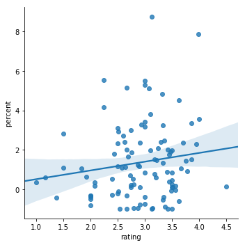

```python
#Move to dataframe for plotting
rates_and_percents = {'rating': k_rated, 'percent': percents}
k_RandP_df = pd.DataFrame(data=rates_and_percents)

sns.lmplot(x='rating', y='percent',data=k_RandP_df, fit_reg=True)
```

```python
k_RandP_df['rating'].corr(k_RandP_df['percent'])
```

```
0.14864167675369724
```

## 4. Exploring Data

In this section we will be looking into using the top three tags in conjuction with the genre of the movie to see if we can predict if it will fail.  
I want to have a column of the dataframe which will describe by our standards if a movie failed or not. 1 indicates net profit > 0 and 0 otherwise.

```python
pass_fail = {}
tester = k_movies_df_abr
for index, mId in tester.iterrows():
    title = mId['title']
    if(int(mId['revenue']) - int(mId['budget']) > 0):
        result = 1
    else:
        result = 0

    pass_fail[title] = result
```

Next I want to get all the budgets. Putting them into a dict will help when we combine the Dataframes.

```python
budgets = {}
for index, mId in k_movies_df_abr.iterrows():
    title = mId['title']
    budgets[title] = mId['budget']
```

Now I will combine the data, you will notice I left out ratings, this is because as we saw earlier, they are not as heavily correlated with non failure as I had hoped.

```python
mix_df = {'title':[],'movieId':[],'genres':[],'budget':[],'fail':[]}
for index, row in m_movies_df_abr.iterrows():
    title = row['title']
    #ensure all our data has genres and removing duplicates
    if(row['genres'] != '(no genres listed)' and not (title in mix_df['title'])):
        for genre in row['genres'].split('|'):
            mix_df['title'].append(row['title'])
            mix_df['budget'].append(budgets[title])
            mix_df['fail'].append(pass_fail[title])
            mix_df['genres'].append(genre)
            mix_df['movieId'].append(row['movieId'])
km_df = pd.DataFrame.from_dict(mix_df)
km_df.head()
```

|  | title | movieId | genres | budget | fail |
| --- | --- | --- | --- | --- | --- |
| 0 | Safe | 190 | Thriller | 30000000 | 1 |
| 1 | Priest | 299 | Drama | 60000000 | 1 |
| 2 | Beauty and the Beast | 595 | Animation | 33000000 | 1 |
| 3 | Beauty and the Beast | 595 | Children | 33000000 | 1 |
| 4 | Beauty and the Beast | 595 | Fantasy | 33000000 | 1 |

Now we have a dataframe with all the ids from movielens (which we will use to get out tags) the movie title, genre, budget, and variable indicating if it failed or not. We also expanded the genre catagory so movies with multiple genres have multiple entries.  
I want to focus on the top three catagories, so I am going to plot the data as a barchart. Hopefully this will allow me to pick the three most popular genres.

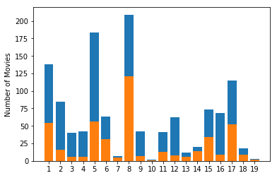

```python
grouped = km_df.groupby('genres')

names = []
fails = []
success = []
for name, group in grouped:
    sucs = sum(group['fail'])
    names.append(name)
    fails.append(len(group['fail']) - sucs)
    success.append(sucs)
#Going to do a stacked bar to compare failures
p1 = plt.bar(names, success)
p2 = plt.bar(names, fails)

plt.ylabel('Number of Movies')
plt.xticks(names, range(1,len(names)+1))
plt.show()
```

```python
num = 1
for g in names:
    print(str(num) + ':' + g)
    num = num+1
```

```
1:Action
2:Adventure
3:Animation
4:Children
5:Comedy
6:Crime
7:Documentary
8:Drama
9:Fantasy
10:Film-Noir
11:Horror
12:IMAX
13:Musical
14:Mystery
15:Romance
16:Sci-Fi
17:Thriller
18:War
19:Western
```

```python
#As we can see, the 3 most popular are Action, Comedy, and Drama
three_genre_df = km_df.loc[km_df['genres'].isin(['Action','Comedy','Drama'])]
three_genre_df
```

|  | title | movieId | genres | budget | fail |
| --- | --- | --- | --- | --- | --- |
| 1 | Priest | 299 | Drama | 60000000 | 1 |
| 8 | Stalingrad | 760 | Drama | 30000000 | 1 |
| 10 | Carrie | 1345 | Drama | 30000000 | 1 |
| 17 | Hercules | 1566 | Comedy | 100000000 | 1 |
| 19 | Conan the Barbarian | 1587 | Action | 90000000 | 0 |
| 22 | Godzilla | 1882 | Action | 160000000 | 1 |
| 26 | Fright Night | 2867 | Comedy | 17000000 | 1 |
| 29 | Total Recall | 2916 | Action | 125000000 | 1 |
| 33 | RoboCop | 2985 | Action | 120000000 | 1 |
| 35 | RoboCop | 2985 | Drama | 120000000 | 1 |
| 38 | Miss Julie | 3116 | Drama | 5500000 | 0 |
| 39 | Teenage Mutant Ninja Turtles | 3438 | Action | 125000000 | 1 |
| 41 | Teenage Mutant Ninja Turtles | 3438 | Comedy | 125000000 | 1 |
| 44 | Red Dawn | 3441 | Action | 65000000 | 0 |
| 45 | Red Dawn | 3441 | Drama | 65000000 | 0 |
| 47 | Arthur | 3524 | Comedy | 40000000 | 1 |
| 49 | Footloose | 3791 | Drama | 24000000 | 1 |
| 52 | Beautiful Creatures | 4242 | Comedy | 60000000 | 1 |
| 54 | Beautiful Creatures | 4242 | Drama | 60000000 | 1 |
| 56 | Cocktail | 4487 | Drama | 6400000 | 1 |
| 59 | Wuthering Heights | 5035 | Drama | 8000000 | 0 |
| 60 | Under the Skin | 5150 | Drama | 13300000 | 0 |
| 61 | Joe | 5340 | Drama | 4000000 | 0 |
| 62 | Endless Love | 5729 | Drama | 20000000 | 1 |
| 64 | Neighbors | 5773 | Comedy | 18000000 | 1 |
| 65 | Straw Dogs | 6301 | Drama | 25000000 | 0 |
| 67 | Promised Land | 6917 | Drama | 15000000 | 0 |
| 68 | Project X | 7019 | Comedy | 12000000 | 1 |
| 69 | Project X | 7019 | Drama | 12000000 | 1 |
| 71 | No Good Deed | 7226 | Drama | 13200000 | 1 |
| ... | ... | ... | ... | ... | ... |
| 1618 | Aadukalam | 156712 | Action | 4000000 | 1 |
| 1619 | Aadukalam | 156712 | Drama | 4000000 | 1 |
| 1621 | Arrambam | 157553 | Action | 9200000 | 1 |
| 1622 | Arrambam | 157553 | Drama | 9200000 | 1 |
| 1624 | Mankatha | 157557 | Action | 6100000 | 1 |
| 1626 | Veeram | 157575 | Action | 5900000 | 1 |
| 1627 | Finding Mr. Right | 159083 | Comedy | 4881000 | 1 |
| 1629 | Boris - Il film | 159853 | Comedy | 3347850 | 0 |
| 1632 | The Guillotines | 167478 | Action | 15000000 | 0 |
| 1634 | The Guillotines | 167478 | Drama | 15000000 | 0 |
| 1637 | The Best Movie 3-DE | 171545 | Comedy | 6500000 | 1 |
| 1638 | Easy on the Eyes | 172435 | Comedy | 2153912 | 1 |
| 1641 | Lucky Island | 172441 | Comedy | 2000000 | 1 |
| 1642 | The Heat | 172679 | Comedy | 43000000 | 1 |
| 1644 | The Spy | 172727 | Action | 6000000 | 0 |
| 1647 | That still Karloson! | 172885 | Comedy | 4000000 | 1 |
| 1649 | Black Rose | 173405 | Action | 7000000 | 0 |
| 1651 | Black Rose | 173405 | Drama | 7000000 | 0 |
| 1652 | Mommies, Happy New Year! | 174597 | Comedy | 2000000 | 1 |
| 1653 | Mommies, Happy New Year! | 174597 | Drama | 2000000 | 1 |
| 1654 | Pregnant | 174601 | Comedy | 2000000 | 1 |
| 1655 | On the Hook! | 174613 | Comedy | 3000000 | 0 |
| 1657 | All at Once | 176129 | Comedy | 750000 | 0 |
| 1659 | The Hunt | 179089 | Action | 3800000 | 1 |
| 1662 | The Eagle | 181007 | Action | 25000000 | 1 |
| 1663 | The Eagle | 181007 | Drama | 25000000 | 1 |
| 1665 | The Monk | 181549 | Drama | 11000000 | 0 |
| 1669 | The Family | 190223 | Drama | 30000000 | 1 |
| 1671 | Underdogs | 191271 | Drama | 22000000 | 1 |
| 1672 | The Apparition | 192223 | Drama | 17000000 | 0 |

761 rows × 5 columns

Now we will get the three most relevant tags to each movie and add them to the dataframe. These are going to be the most important feature for predicting.

```python
tags_list = []
drop_list = [] #this will store the indecies with no tags so we can drop them without messing up alignment
grouped = m_scores_df.groupby(['movieId'])
for index, row in three_genre_df.iterrows():
    mId = row['movieId']
    movies_list = []
    try:
        movie = grouped.get_group(mId)
        movie = movie[movie['relevance']>.15].sort_values(['relevance'], ascending=False).head(3) #Get top 3 relevant tags
        for index, row in movie.iterrows():
            movies_list.append(m_tags_df.loc[m_tags_df['tagId'] == row['tagId']]['tag'].values[0])

    except:
        #doesnt exist so an empty tag list will be appended
        drop_list.append(index)
    tags_list.append(movies_list)

three_genre_df['tags'] = tags_list
```

```python
#Now Droping those entries with no tags
three_genre_df.drop(drop_list, inplace=True)
```

```python
three_genre_df
```

|  | title | movieId | genres | budget | fail | tags |
| --- | --- | --- | --- | --- | --- | --- |
| 1 | Priest | 299 | Drama | 60000000 | 1 | [catholicism, sexual abuse, gay] |
| 8 | Stalingrad | 760 | Drama | 30000000 | 1 | [germany, wwii, world war ii] |
| 10 | Carrie | 1345 | Drama | 30000000 | 1 | [horror, bullying, creepy] |
| 17 | Hercules | 1566 | Comedy | 100000000 | 1 | [disney animated feature, animation, mythology] |
| 19 | Conan the Barbarian | 1587 | Action | 90000000 | 0 | [fantasy, arnold, wizards] |
| 22 | Godzilla | 1882 | Action | 160000000 | 1 | [saturn award (best special effects), special ... |
| 26 | Fright Night | 2867 | Comedy | 17000000 | 1 | [vampires, vampire, horror] |
| 29 | Total Recall | 2916 | Action | 125000000 | 1 | [futuristic, scifi, science fiction] |
| 33 | RoboCop | 2985 | Action | 120000000 | 1 | [dystopic future, cyborgs, futuristic] |
| 35 | RoboCop | 2985 | Drama | 120000000 | 1 | [dystopic future, cyborgs, futuristic] |
| 39 | Teenage Mutant Ninja Turtles | 3438 | Action | 125000000 | 1 | [ninja, adapted from:comic, based on a comic] |
| 41 | Teenage Mutant Ninja Turtles | 3438 | Comedy | 125000000 | 1 | [ninja, adapted from:comic, based on a comic] |
| 44 | Red Dawn | 3441 | Action | 65000000 | 0 | [action, war, small town] |
| 45 | Red Dawn | 3441 | Drama | 65000000 | 0 | [action, war, small town] |
| 47 | Arthur | 3524 | Comedy | 40000000 | 1 | [quotable, funny as hell, classic] |
| 49 | Footloose | 3791 | Drama | 24000000 | 1 | [dancing, dance, teen movie] |
| 52 | Beautiful Creatures | 4242 | Comedy | 60000000 | 1 | [women, original, sexy] |
| 54 | Beautiful Creatures | 4242 | Drama | 60000000 | 1 | [women, original, sexy] |
| 56 | Cocktail | 4487 | Drama | 6400000 | 1 | [mentor, love story, girlie movie] |
| 59 | Wuthering Heights | 5035 | Drama | 8000000 | 0 | [adapted from:book, adaptation, passionate] |
| 61 | Joe | 5340 | Drama | 4000000 | 0 | [violence, vigilante, nudity (topless - notable)] |
| 62 | Endless Love | 5729 | Drama | 20000000 | 1 | [love story, love, teen movie] |
| 64 | Neighbors | 5773 | Comedy | 18000000 | 1 | [nudity (topless - notable), weird, saturday n... |
| 65 | Straw Dogs | 6301 | Drama | 25000000 | 0 | [rape, violence, brutality] |
| 68 | Project X | 7019 | Comedy | 12000000 | 1 | [animals, animal movie, family] |
| 69 | Project X | 7019 | Drama | 12000000 | 1 | [animals, animal movie, family] |
| 71 | No Good Deed | 7226 | Drama | 13200000 | 1 | [bank robbery, robbery, neo-noir] |
| 73 | Trespass | 7284 | Action | 36000000 | 0 | [treasure hunt, gangster, gangsters] |
| 79 | Shame | 7936 | Drama | 6500000 | 1 | [bleak, war, downbeat] |
| 85 | Rush | 8158 | Drama | 38000000 | 1 | [undercover cop, addiction, drugs] |
| ... | ... | ... | ... | ... | ... | ... |
| 1412 | Black or White | 117861 | Drama | 9000000 | 1 | [family drama, touching, feel-good] |
| 1413 | Still Alice | 117881 | Drama | 5000000 | 1 | [oscar (best actress), heartbreaking, drama] |
| 1415 | Paddington | 117887 | Comedy | 55000000 | 1 | [heartwarming, based on a book, family] |
| 1416 | Clouds of Sils Maria | 118246 | Drama | 6600000 | 0 | [drama, talky, relationships] |
| 1419 | Kill the Messenger | 118354 | Drama | 5000000 | 0 | [conspiracy, journalism, corruption] |
| 1426 | Selma | 118700 | Drama | 20000000 | 1 | [history, segregation, historical] |
| 1427 | Unbroken | 118702 | Drama | 65000000 | 1 | [survival, world war ii, wwii] |
| 1432 | Mommy | 118896 | Drama | 4900000 | 0 | [mother-son relationship, emotional, heartbrea... |
| 1433 | A Most Violent Year | 118898 | Action | 20000000 | 0 | [organized crime, gangster, new york] |
| 1435 | A Most Violent Year | 118898 | Drama | 20000000 | 0 | [organized crime, gangster, new york] |
| 1437 | Wild | 118900 | Drama | 15000000 | 1 | [based on a book, solitude, wilderness] |
| 1438 | Big Eyes | 118985 | Drama | 10000000 | 1 | [art, artistic, biographical] |
| 1439 | The Interview | 119141 | Action | 44000000 | 0 | [comedy, satire, absurd] |
| 1440 | The Interview | 119141 | Comedy | 44000000 | 0 | [comedy, satire, absurd] |
| 1443 | Night at the Museum: Secret of the Tomb | 119155 | Comedy | 127000000 | 1 | [franchise, family, kids and family] |
| 1448 | PK | 120138 | Comedy | 13000000 | 1 | [god, religion, alien] |
| 1449 | PK | 120138 | Drama | 13000000 | 1 | [god, religion, alien] |
| 1460 | Taken 3 | 120635 | Action | 48000000 | 1 | [action, chase, revenge] |
| 1463 | The Woman in Black 2: Angel of Death | 120825 | Drama | 1000000 | 1 | [horror, scary, creepy] |
| 1487 | The Gambler | 124859 | Drama | 25000000 | 1 | [addiction, los angeles, gambling] |
| 1489 | 99 Homes | 127178 | Drama | 8000000 | 0 | [single father, corruption, greed] |
| 1500 | Suite Française | 130474 | Drama | 15000000 | 0 | [world war ii, wwii, france] |
| 1505 | Kung Fu Jungle | 131270 | Action | 25000000 | 0 | [martial arts, kung fu, wuxia] |
| 1508 | Infinitely Polar Bear | 131658 | Comedy | 6700000 | 0 | [father daughter relationship, single father, ... |
| 1509 | Infinitely Polar Bear | 131658 | Drama | 6700000 | 0 | [father daughter relationship, single father, ... |
| 1511 | Samba | 131830 | Comedy | 20000000 | 0 | [france, drama, immigrants] |
| 1512 | Samba | 131830 | Drama | 20000000 | 0 | [france, drama, immigrants] |
| 1528 | 5 Flights Up | 134851 | Drama | 6000000 | 0 | [pornography, marriage, original] |
| 1529 | Tanu Weds Manu | 134867 | Comedy | 400000 | 0 | [feel-good, bollywood, feel good movie] |
| 1530 | Tanu Weds Manu | 134867 | Drama | 400000 | 0 | [feel-good, bollywood, feel good movie] |

575 rows × 6 columns

We need to build a dict one more time so we only have one tag per entry. I am going to make a dict and rebuild the dataframe just to be sure everything is how we want it.  
*We do not really need movieId anymore, but I will keep it in in case we look at something else later.

```python
tag_df = {'title':[],'movieId':[],'genres':[],'budget':[],'fail':[],'tag':[]}
for index, row in three_genre_df.iterrows():
    title = row['title']
    for t in row['tags']:
        tag_df['tag'].append(t)
        tag_df['title'].append(row['title'])
        tag_df['movieId'].append(int(row['movieId']))
        tag_df['budget'].append(int(row['budget']))
        tag_df['fail'].append(int(row['fail']))
        tag_df['genres'].append(row['genres'])

final_df = pd.DataFrame.from_dict(tag_df)
```

Currently we have a lot of string values, the tags, and the genres. We will be using LabelEncoder to encode these toooooooo numeric values so we can use them for prediction.

```python
from sklearn import preprocessing
le = preprocessing.LabelEncoder()

num_tag = le.fit_transform(final_df['tag'].values) #encoded tags
num_genre = le.fit_transform(final_df['genres']) #encdoed genres

final_df['num_genre'] = num_genre
final_df['num_tag'] = num_tag

final_df.head()
```

|  | title | movieId | genres | budget | fail | tag | num_genre | num_tag |
| --- | --- | --- | --- | --- | --- | --- | --- | --- |
| 0 | Priest | 299 | Drama | 60000000 | 1 | catholicism | 2 | 67 |
| 1 | Priest | 299 | Drama | 60000000 | 1 | sexual abuse | 2 | 343 |
| 2 | Priest | 299 | Drama | 60000000 | 1 | gay | 2 | 166 |
| 3 | Stalingrad | 760 | Drama | 30000000 | 1 | germany | 2 | 170 |
| 4 | Stalingrad | 760 | Drama | 30000000 | 1 | wwii | 2 | 434 |

```python
from sklearn import tree
from sklearn import model_selection

#breaking up the dataframe for testing purposes
train = final_df[0:1500]
test = final_df[1500:]

feats = ['budget','num_genre','num_tag']
features = train[feats]
target = train[['fail']]

X = features
y = target['fail']

clf = tree.DecisionTreeClassifier()
clf = clf.fit(X,y)
```

So now the classifier is ready. The following code shows us what the tree looks like. It also exports it to a pdf which is easier to view because the graph is pretty big.  
You may need to run conda install python-graphviz to import this module.

```python
import graphviz
dot_data = tree.export_graphviz(clf, out_file=None,
                                feature_names = feats,
                                filled=True, rounded=True)
graph = graphviz.Source(dot_data)
graph.render("movies")
graph
```

[figure not shown]

```python
print("Score: " + str(clf.score(X,y)))
feature_weights = clf.feature_importances_.tolist()
print('Bugdget: ' + str(feature_weights[0]))
print('Genre: ' + str(feature_weights[1]))
print('Tag: ' + str(feature_weights[2]))
```

```
Score: 0.988666666667
Bugdget: 0.4905827075588545
Genre: 0.028324081508385068
Tag: 0.4810932109327603
```

```python
from sklearn.metrics import accuracy_score

y_test = test[['fail']]
X_test = test[feats]
preds = clf.predict(X_test)

accuracy_score(y_test['fail'].values, preds)
```

```
0.57333333333333336
```

This score is lower than I was hoping for. This is not our final result though. Remember we broke movie up by genre and by tags, but these movies always shared the failed trait. If we recombine the rows we separated and take prediction made on the majority of the rows, I am sure we will increase the score.

```python
test['predictions'] = preds
grouped_test = test.groupby('title')


together_again = {'title':[],'actual':[],'prediction':[]}

for name, row in grouped_test:
    if(1 in row['fail'].values):
        actual = 1
    else:
        actual = 0
    total = 0
    pred_total = 0
    for index, stuff in row.iterrows():
        pred_total = pred_total + stuff['predictions']
        total = total+1
    if(float(total/2) < float(pred_total)):
        final_prediction = 1
    else:
        final_prediction = 0

    together_again['title'].append(name)
    together_again['actual'].append(actual)
    together_again['prediction'].append(final_prediction)

final_results_df = pd.DataFrame.from_dict(together_again)
accuracy_score(final_results_df['actual'].values, final_results_df['prediction'].values)
```

```
0.6166666666666667
```

Well while the score went up, it is still not as accurate as I would have liked. Due to time constraints I will not be able to continue to explore this, but I encourgae you to continue. I wonder if we took more tags? What if we were able to get actors and directors of a movie and take them into account? There are plenty of questions that can be answered playing around with this data.

## 6. Conclusion

Unfortunately I was not able to predict a movies failure as accurately as I would have liked. However, we still found out some pretty interesting facts, I assumed ratings would have had a stronger correlation with net profits, and I found out how some suggestion algorthms work (using the tags we used here) and I will provide a link to that below. Finally, thank you for reading through my tutorial, and I will gladly welcome any movie discussion.

## Imports and External Links

```python
#Libraries
import pandas as pd
import numpy as np
from sklearn.metrics import accuracy_score
import graphviz
import matplotlib.pyplot as plt
import seaborn as sns
import json
import ast
import warnings
warnings.filterwarnings('ignore') #Used this to hide expected warnings
```

Kaggle Movies Data: https://www.kaggle.com/rounakbanik/the-movies-dataset  
MovieLens Data: https://grouplens.org/datasets/movielens/latest/  
Tags: http://files.grouplens.org/papers/tag_genome.pdf  
Decision Trees: https://en.wikipedia.org/wiki/Decision_tree